# hw2

William Huang PSET 2 - CPSC 475

**Problem 1a.**

```python
# Import Dependencies
from nsimulator import nsimulator
import matplotlib.pyplot as plt
import numpy as np
import scipy
```

```python
# Set times for plots

norecordtime = 0.0; # Integration time (seconds) when not recording
                    # membrane potentials
recordtime = 0.2; # Integration time for recorded values
```

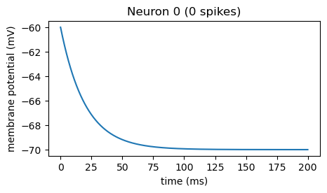

```python
# Using initial membrane potential of -60 mV with a current of 0 nA
nsim = nsimulator(1)
start_potential = -60
ie = 0; # nA

# Set initial membrane potential
nsim.set_mpotential(0, start_potential)
# Define injected current
nsim.set_Ie(0, ie)

nsim.simulate_timeinterval(norecordtime, recordtime)
nsim.plot_membranepotentials([0])
```

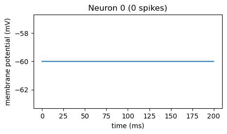

```python
# Using initial membrane potential of -60 mV with a current of 1 nA
ie = 1
nsim.set_mpotential(0, start_potential)
nsim.set_Ie(0, ie)

nsim.simulate_timeinterval(norecordtime, recordtime)
nsim.plot_membranepotentials([0])
```

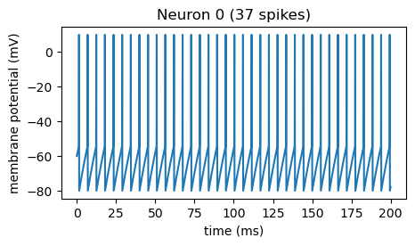

```python
# Using initial membrane potential of -60 mV with a current of 10 nA
ie = 10
nsim.set_mpotential(0, start_potential)
nsim.set_Ie(0, ie)

nsim.simulate_timeinterval(norecordtime, recordtime)
nsim.plot_membranepotentials([0])
```

When you vary the input current, the resting membrane potential varies according to the specific input. For example, when the current that is injected is 0 nA, the resting membrane potential over time solely decreases as the lack of input current and the existence of leakage in ions results in a gradual decrease in membrane potential as the membrane potential slowly is restored back to the resting potential at -70 mV. In the second case (when the injected current is 1 nA), the membrane potential stays constant at the initial membrane potential of -60 mV because the 1 nA does not provide a large enough current to induce a spike (the voltage does not pass the threshold). However, there is also enough current to balance the injected current, leading to a constant potential at the initial membrane potential. Finally, in the last case, where the injected current is 10 nA, the provided current is large enough to offset the leakage while bringing the potential to a value large enough to depolarize and reach the action potential, leading to the spikes (37 in total due to the constant current input).

**Problem 1b.**

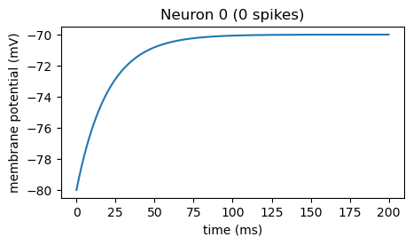

```python
# Using initial membrane potential of -80 mV with a current of 0 nA
nsim = nsimulator(1)
start_potential = -80
ie = 0; # nA

# Set initial membrane potential
nsim.set_mpotential(0, start_potential)
# Define injected current
nsim.set_Ie(0, ie)

nsim.simulate_timeinterval(norecordtime, recordtime)
nsim.plot_membranepotentials([0])
```

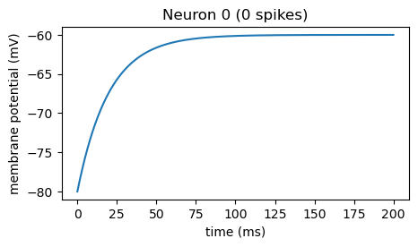

```python
# Using initial membrane potential of -80 mV with a current of 1 nA
ie = 1
nsim.set_mpotential(0, start_potential)
nsim.set_Ie(0, ie)

nsim.simulate_timeinterval(norecordtime, recordtime)
nsim.plot_membranepotentials([0])
```

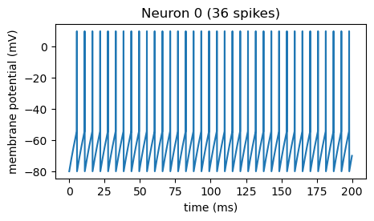

```python
# Using initial membrane potential of -80 mV with a current of 10 nA
ie = 10
nsim.set_mpotential(0, start_potential)
nsim.set_Ie(0, ie)

nsim.simulate_timeinterval(norecordtime, recordtime)
nsim.plot_membranepotentials([0])
```

In the case where the initial membrane potential is -80 mV, there are many differences in the change in membrane potential. In the case where 0 nA of current is injected in the neuron, the membrane potential slowly increases from the initial membrane potential of -80 mV to the resting potential of the neuron (-70 mV) due to leakage of the neuron. In the case where 1 nA of current is injected into the neuron, the behavior is similar, as the membrane potential starts from the membrane potential of -80 mV and slowly increases to -60 mV where it stabilizes. In this case, the amount of current is not enough to induce depolarization, and thus there are no spikes. However, the the potential that the neuron levels off at is 10 mV greater than the resting potential due to the 1 nA constant current. In the final case where the injected current has 10 nA, the current is strong enough under the integrate-and-fire model, leading to the membrane potential reaching the action potential and causing spikes (continuous due to the constant current input).

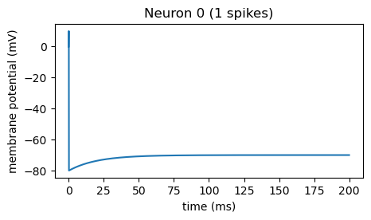

```python
# Using initial membrane potential of 0 mV with a current of 0 nA
nsim = nsimulator(1)
start_potential = 0
ie = 0; # nA

# Set initial membrane potential
nsim.set_mpotential(0, start_potential)
# Define injected current
nsim.set_Ie(0, ie)

nsim.simulate_timeinterval(norecordtime, recordtime)
nsim.plot_membranepotentials([0])
```

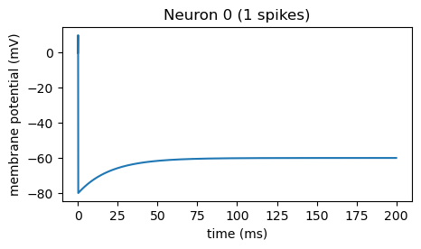

```python
# Using initial membrane potential of 0 mV with a current of 1 nA
ie = 1
nsim.set_mpotential(0, start_potential)
nsim.set_Ie(0, ie)

nsim.simulate_timeinterval(norecordtime, recordtime)
nsim.plot_membranepotentials([0])
```

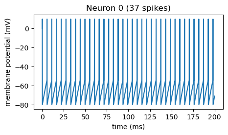

```python
# Using initial membrane potential of 0 mV with a current of 10 nA
ie = 10
nsim.set_mpotential(0, start_potential)
nsim.set_Ie(0, ie)

nsim.simulate_timeinterval(norecordtime, recordtime)
nsim.plot_membranepotentials([0])
```

In the final case where the starting membrane potential is 0 mV, the behavior is also different. In the case where the injected current has 0 nA, there is one spike, and then the neuron enters the refractory period and then reaches the resting potential. The reason why the neuron spikes is because the starting membrane potential is larger than the action potential, causing an immediate spike. Since there is not enough current (0 current), there are no more spikes and the neuron returns to the resting potential. In the second case where there is 1 nA of current injected, the behavior is very similar, where there is 1 spike in the beginning. However, the current is not large enough to bring the membrane potential to the action potential, leading to the neuron leveling off at -60 mV, which is 10 mV higher due to the constant input. Finally, in the last case, the neuron immediately spikes due to the neuron having a starting membrane potential over the action potential, and then continues to spike due to the magnitude of the current being large enough to cause depolarization (37 spikes)

**Problem 1c.**

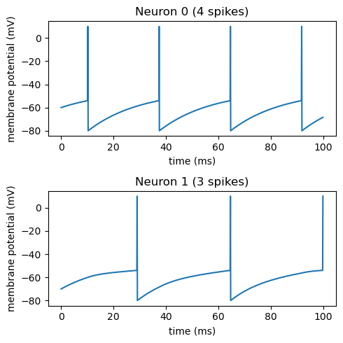

```python
# Simulation of two neurons

# Neuron #1 and #2
nsim2 = nsimulator(2)

start_potential_1 = -60
start_potential_2 = -70

ie = 2.5

# Setting initial potential
nsim2.set_mpotential(0, start_potential_1)
nsim2.set_mpotential(1, start_potential_2)

# Setting current
nsim2.set_Ie(0, ie)
nsim2.set_Ie(1, ie)

# Setting inhibitory connection of 1 on 2
nsim2.make_inhibitory_connection(0, 1)


nsim2.simulate_timeinterval(0, 0.1)
nsim2.plot_membranepotentials([0, 1])
```

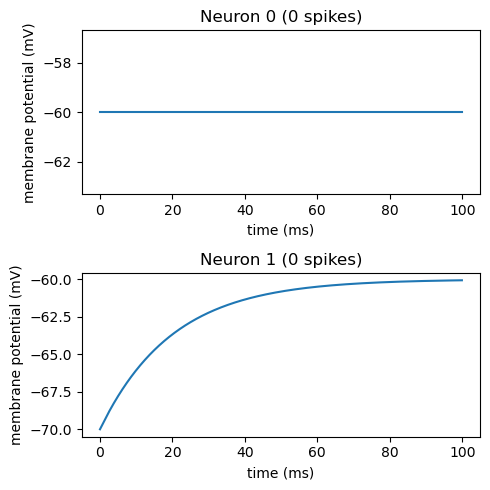

```python
# Simulation of two neurons

# Neuron #1 and #2
nsim2 = nsimulator(2)

start_potential_1 = -60
start_potential_2 = -70

ie = 1

# Setting initial potential
nsim2.set_mpotential(0, start_potential_1)
nsim2.set_mpotential(1, start_potential_2)

# Setting current
nsim2.set_Ie(0, ie)
nsim2.set_Ie(1, ie)

# Setting inhibitory connection of 1 on 2
nsim2.make_inhibitory_connection(0, 1)


nsim2.simulate_timeinterval(0, 0.1)
nsim2.plot_membranepotentials([0, 1])
```

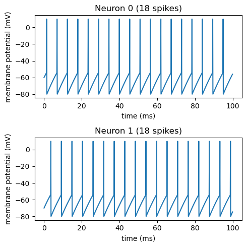

```python
# Simulation of two neurons

# Neuron #1 and #2
nsim2 = nsimulator(2)

start_potential_1 = -60
start_potential_2 = -70

ie = 10

# Setting initial potential
nsim2.set_mpotential(0, start_potential_1)
nsim2.set_mpotential(1, start_potential_2)

# Setting current
nsim2.set_Ie(0, ie)
nsim2.set_Ie(1, ie)

# Setting inhibitory connection of 1 on 2
nsim2.make_inhibitory_connection(0, 1)


nsim2.simulate_timeinterval(0, 0.1)
nsim2.plot_membranepotentials([0, 1])
```

From the observed behaviors of neuron 1 and neuron 2, it is clear that when neuron 1 (the inhibitory neuron fires), it causes a decrease in membrane potential in the neuron that is inhibited (neuron 2). In comparison to the behavior when neuron 2 is not inhibited, the neuron's spikes are shifted, as the inhibition of the neuron causes it to not be able to reach action potential in the same amount of time, delaying depolarization (examples where injected current was 2.5 nA and 10 nA). However, if neuron 1 does not fire, in the case where the injected input is 1 nA, there is no change in effect in neuron 2, as the lack of firing prevented the inhibition and therefore a decrease in membrane potential in neuron 2. In particular, we can see that in graph, neuron 2 toward -60 mV due to the 1 nA, which is the same behavior if there were not an inhibitory neuron.

**Problem 1d.**

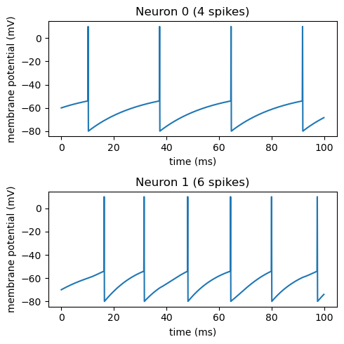

```python
# Simulation of two neurons

# Neuron #1 and #2
nsim2 = nsimulator(2)

start_potential_1 = -60
start_potential_2 = -70

ie = 2.5

# Setting initial potential
nsim2.set_mpotential(0, start_potential_1)
nsim2.set_mpotential(1, start_potential_2)

# Setting current
nsim2.set_Ie(0, ie)
nsim2.set_Ie(1, ie)

# Setting inhibitory connection of 1 on 2
nsim2.make_excitatory_connection(0, 1)


nsim2.simulate_timeinterval(0, 0.1)
nsim2.plot_membranepotentials([0, 1])
```

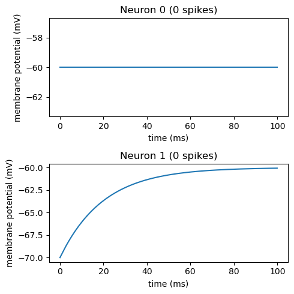

```python
# Simulation of two neurons

# Neuron #1 and #2
nsim2 = nsimulator(2)

start_potential_1 = -60
start_potential_2 = -70

ie = 1

# Setting initial potential
nsim2.set_mpotential(0, start_potential_1)
nsim2.set_mpotential(1, start_potential_2)

# Setting current
nsim2.set_Ie(0, ie)
nsim2.set_Ie(1, ie)

# Setting inhibitory connection of 1 on 2
nsim2.make_inhibitory_connection(0, 1)


nsim2.simulate_timeinterval(0, 0.1)
nsim2.plot_membranepotentials([0, 1])
```

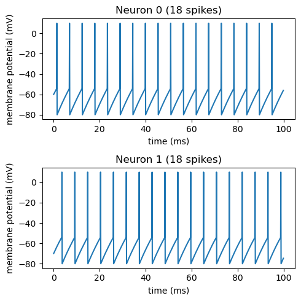

```python
# Simulation of two neurons

# Neuron #1 and #2
nsim2 = nsimulator(2)

start_potential_1 = -60
start_potential_2 = -70

ie = 10

# Setting initial potential
nsim2.set_mpotential(0, start_potential_1)
nsim2.set_mpotential(1, start_potential_2)

# Setting current
nsim2.set_Ie(0, ie)
nsim2.set_Ie(1, ie)

# Setting inhibitory connection of 1 on 2
nsim2.make_inhibitory_connection(0, 1)


nsim2.simulate_timeinterval(0, 0.1)
nsim2.plot_membranepotentials([0, 1])
```

In the excitatory connection, the neuron's behavior also changes. For example, when the injected current is 2.5 nA, the neuron that is excited will spike more frequently due to the added excitatory input from neuron 1 when it spikes itself. In contrast to the inhibitory connection, where a spike in the opposing neuron induces a decrease in membrane potential, a spike in the opposing neuron in this case induces an increase in membrane potential. Therefore, the neuron will be more likely to fire more frequently, as there as an additional positive input with the current that will help push the membrane potential over the action potential. However, if the excitatory neuron does not fire, as in the case where the injected current is 1 nA, there is no effect to the neuron 2, and it will behave in the same way as if there was no connection between the two neurons.

**Problem 2e.**

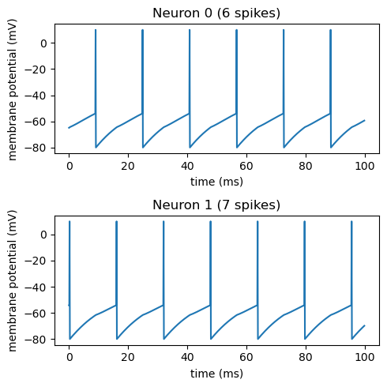

```python
# Simulation of two neurons where one excites the other (and the other way around)

# Neuron #1 and #2
nsim2 = nsimulator(2)

start_potential_1 = -60
start_potential_2 = -60

ie = 2.5

# Setting initial potential
# nsim2.set_mpotential(0, start_potential_1)
# nsim2.set_mpotential(1, start_potential_2)

# Setting current
nsim2.set_Ie(0, ie)
nsim2.set_Ie(1, ie)

# Setting inhibitory connection of 1 on 2
nsim2.make_excitatory_connection(0, 1)
nsim2.make_excitatory_connection(1, 0)


nsim2.simulate_timeinterval(1, 0.1)
nsim2.plot_membranepotentials([0, 1])
```

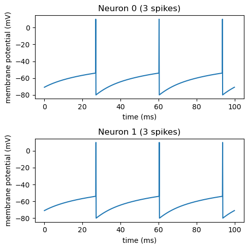

```python
# Simulation of two neurons where one inhibits the other (and the other way around)

# Neuron #1 and #2
nsim2 = nsimulator(2)

start_potential_1 = -60
start_potential_2 = -60

ie = 2.5

# Setting initial potential
# nsim2.set_mpotential(0, start_potential_1)
# nsim2.set_mpotential(1, start_potential_2)

# Setting current
nsim2.set_Ie(0, ie)
nsim2.set_Ie(1, ie)

# Setting inhibitory connection of 1 on 2
nsim2.make_inhibitory_connection(0, 1)
nsim2.make_inhibitory_connection(1, 0)


nsim2.simulate_timeinterval(1, 0.1)
nsim2.plot_membranepotentials([0, 1])
```

In the beginning, when I did not remove calls to nsim.set_mpotential, there was no phase offset. However, once removing this function call, I observe a phase offset between the neurons when they excite one another. This makes sense because if the two neurons were to start at the same membrane potential and are injected the same current, they would spike at the same time and thus there would not be any offset. However, if they have different initial membrane potentials, then they would spike at different times. If the two neurons did not start at the same membrane potential, then, the firing of one will encourage the firing of the other, leading to an amplificiation in the difference in firing times. However, for the inhibitory connections, the neurons tend to synchronize their spikes in both cases where I intitially set the membrane potential and when I do not. This hold true because if one neuron spikes first, then it will slow down the spiking of the other, and vice versa (when one spikes it slows down the other, allowing the spiking neuron to catch up). Over time, this will eventually align the spiking, which will cause them to spike at the same time.

**Problem 2a.**

result = transpose([3 6 9 12 9])

**Problem 2b.**

for all scalars, a, in the real numbers, where T is the linear transformation representing the tridiagonal matrix from a, T(av) = aT(v)

**Problem 2c.**

since a + b = v, T(a + b) = T(a) = T(b) = T(v)

**Problem 2d.**

\begin{bmatrix} 1/3 & 1/3 & 1/3 & 0 & 0 & 0\\ 0 & 0 & 0 & 1/3 & 1/3 & 1/3 \end{bmatrix}

**Problem 2e.**

```python
# Initializing the matrix

t = np.empty((10, 10))

for i in range(10):
    for j in range(10):
        if j == i:
            t[i, j] = 1
        elif j == i - 1:
            t[i, j] = -0.2
        elif j == i + 1:
            t[i, j] = -0.2
        else:
            t[i, j] = 0

# Plot matrix
for row in t:
    print(row)
```

```
[ 1.  -0.2  0.   0.   0.   0.   0.   0.   0.   0. ]
[-0.2  1.  -0.2  0.   0.   0.   0.   0.   0.   0. ]
[ 0.  -0.2  1.  -0.2  0.   0.   0.   0.   0.   0. ]
[ 0.   0.  -0.2  1.  -0.2  0.   0.   0.   0.   0. ]
[ 0.   0.   0.  -0.2  1.  -0.2  0.   0.   0.   0. ]
[ 0.   0.   0.   0.  -0.2  1.  -0.2  0.   0.   0. ]
[ 0.   0.   0.   0.   0.  -0.2  1.  -0.2  0.   0. ]
[ 0.   0.   0.   0.   0.   0.  -0.2  1.  -0.2  0. ]
[ 0.   0.   0.   0.   0.   0.   0.  -0.2  1.  -0.2]
[ 0.   0.   0.   0.   0.   0.   0.   0.  -0.2  1. ]
```

**Problem 2f.**

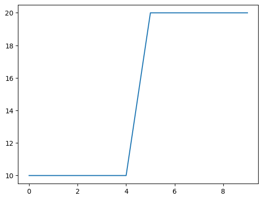

```python
# Creating the matrix
m = np.array([10, 10, 10, 10, 10, 20, 20, 20, 20, 20])

# Plotting the matrix
plt.plot(m)
```

```python
# Transfomring the matrix
t = np.array(t)
m = np.array(m)
out = np.dot(t, m)

# Print output
print(out)
```

```
[ 8.  6.  6.  6.  4. 14. 12. 12. 12. 16.]
```

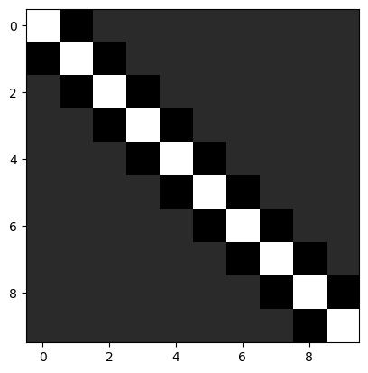

```python
plt.imshow(t, cmap="gray")
```

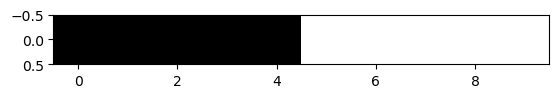

```python
m_2d = m.reshape(1, 10)
plt.imshow(m_2d, cmap = "gray")
```

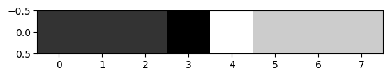

```python
out_clean = out[1:9]
out_2d = out_clean.reshape(1, 8)
plt.imshow(out_2d, cmap = "gray")
```

**Problem 2g.**

```python
# Initializing the matrix

t2 = np.empty((10, 10))

for i in range(10):
    for j in range(10):
        if j == i:
            t2[i, j] = 1
        elif j == i - 1:
            t2[i, j] = 1/3
        elif j == i + 1:
            t2[i, j] = 1/3
        else:
            t2[i, j] = 0

# Plot matrix
for row in t2:
    print(row)
```

```
[1.         0.33333333 0.         0.         0.         0.
 0.         0.         0.         0.        ]
[0.33333333 1.         0.33333333 0.         0.         0.
 0.         0.         0.         0.        ]
[0.         0.33333333 1.         0.33333333 0.         0.
 0.         0.         0.         0.        ]
[0.         0.         0.33333333 1.         0.33333333 0.
 0.         0.         0.         0.        ]
[0.         0.         0.         0.33333333 1.         0.33333333
 0.         0.         0.         0.        ]
[0.         0.         0.         0.         0.33333333 1.
 0.33333333 0.         0.         0.        ]
[0.         0.         0.         0.         0.         0.33333333
 1.         0.33333333 0.         0.        ]
[0.         0.         0.         0.         0.         0.
 0.33333333 1.         0.33333333 0.        ]
[0.         0.         0.         0.         0.         0.
 0.         0.33333333 1.         0.33333333]
[0.         0.         0.         0.         0.         0.
 0.         0.         0.33333333 1.        ]
```

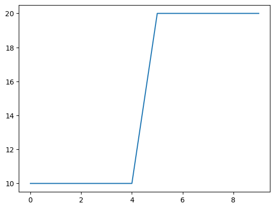

```python
# Creating the input matrix 1
m1 = np.array([10, 10, 10, 10, 10, 20, 20, 20, 20, 20])

# Plotting the matrix
plt.plot(m1)
```

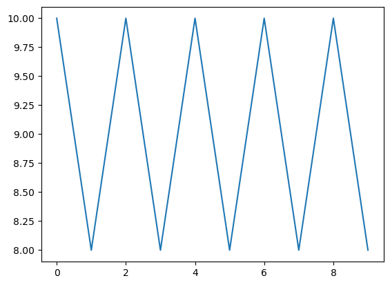

```python
# Creating the input matrix 2
# Creating the matrix
m2 = np.array([10, 8, 10, 8, 10, 8, 10, 8, 10, 8])

# Plotting the matrix
plt.plot(m2)
```

```python
# Transforming the two inputs with the positive network
out1 = np.dot(t2, m1)
out2 = np.dot(t2, m2)

print(out1)
print(out2)
```

```
[13.33333333 16.66666667 16.66666667 16.66666667 20.         30.
 33.33333333 33.33333333 33.33333333 26.66666667]
[12.66666667 14.66666667 15.33333333 14.66666667 15.33333333 14.66666667
 15.33333333 14.66666667 15.33333333 11.33333333]
```

```python
# Without boundaries
out1_cleaned = out1[1:9]
out2_cleaned = out2[1:9]

print(out1_cleaned)
print(out2_cleaned)
```

```
[16.66666667 16.66666667 16.66666667 20.         30.         33.33333333
 33.33333333 33.33333333]
[14.66666667 15.33333333 14.66666667 15.33333333 14.66666667 15.33333333
 14.66666667 15.33333333]
```

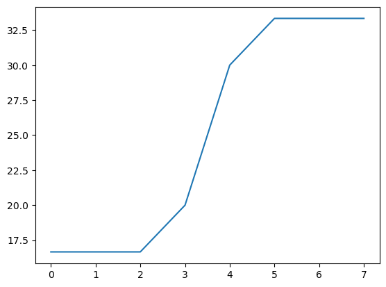

```python
plt.plot(out1_cleaned)
```

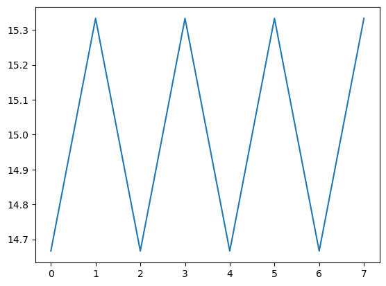

```python
plt.plot(out2_cleaned)
```

Qualitatively, this network tries to minimize differences in the overall data. For example, for the first vector input, the data had 5 10s followed by 5 20s. The output of this vector after being transformed by the matrix smoothens out the large difference in the input data so that the transition from element 4 to 5 appears not as large. This is because there is a gradual increase from element 3 to 4 and a leveling out from element 5 to 6. Similarily, in the second vector input, we can see that the differences between each element have been reduced.

**Problem 2e.**

I expect the combined action of this system on the input to be equivalent to result of the identity on the input. This is because the first feedforward network would enlarge differences between the data while the second network would minimize the differences in the data. To build a single matrix to represent the action, we can take a dot product of the first matrix by the second matrix, leaving a 10 x 10 matrix representing the transformation composition.

```python
# Building the composition
comp = np.dot(t, t2)
print(comp)
```

```
[[ 0.93333333  0.13333333 -0.06666667  0.          0.          0.
   0.          0.          0.          0.        ]
 [ 0.13333333  0.86666667  0.13333333 -0.06666667  0.          0.
   0.          0.          0.          0.        ]
 [-0.06666667  0.13333333  0.86666667  0.13333333 -0.06666667  0.
   0.          0.          0.          0.        ]
 [ 0.         -0.06666667  0.13333333  0.86666667  0.13333333 -0.06666667
   0.          0.          0.          0.        ]
 [ 0.          0.         -0.06666667  0.13333333  0.86666667  0.13333333
  -0.06666667  0.          0.          0.        ]
 [ 0.          0.          0.         -0.06666667  0.13333333  0.86666667
   0.13333333 -0.06666667  0.          0.        ]
 [ 0.          0.          0.          0.         -0.06666667  0.13333333
   0.86666667  0.13333333 -0.06666667  0.        ]
 [ 0.          0.          0.          0.          0.         -0.06666667
   0.13333333  0.86666667  0.13333333 -0.06666667]
 [ 0.          0.          0.          0.          0.          0.
  -0.06666667  0.13333333  0.86666667  0.13333333]
 [ 0.          0.          0.          0.          0.          0.
   0.         -0.06666667  0.13333333  0.93333333]]
```

```python
# Applying composition on input
input = np.array([10, 10, 10, 10, 10, 10, 10, 10, 10, 10])

output = np.dot(comp, input)
print(output)
```

```
[10.         10.66666667 10.         10.         10.         10.
 10.         10.         10.66666667 10.        ]
```

From the output, we can see that hypothesis has been confimed, as all the output data values are the same as the input (ignoring the effect of the boundary values).

**Problem 3a.**

```python
# Intializing the impulse response
input1 = np.array([0, 0, 0, 0, 0, 4, 4, 4, 4, 4, 0, 0, 0, 0, 0, 0])
input2 = np.array([0, 0, 0, 0, 0, 3, 2, 1, 0, 0, 0, 0, 0, 0, 0, 0])
impulse_response1 = np.array([0, 0, 0, 0, 0, 4, 4, 4, 4, 4, 0, 0, 0, 0, 0, 0])
impulse_response2 = np.array([0, 0, 0, 0, 4, 4, 0, 0, 0, 4, 4, 0, 0, 0, 0, 0])
```

```python
# Calculating convolutions
res1 = np.convolve(input1, impulse_response1, mode="same")
res1
```

```
array([ 0,  0,  0, 16, 32, 48, 64, 80, 64, 48, 32, 16,  0,  0,  0,  0])
```

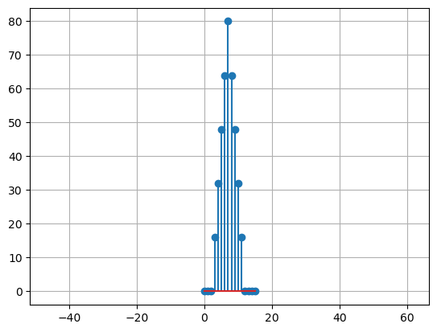

```python
plt.stem(res1)
plt.axis('equal')
plt.grid()
```

```python
res2 = np.convolve(input2, impulse_response2, mode="same")
res2
```

```
array([ 0,  0, 12, 20, 12,  4,  0, 12, 20, 12,  4,  0,  0,  0,  0,  0])
```

**Problem 3b.**

```python
input_2d = np.array([[1, 2, 3, 4], [5, 6, 7, 8,], [9, 10, 11, 12], [13, 14, 15, 16]])
kernel = np.array([[-1, -2, -1], [0, 0, 0], [1, 2, 1]])

scipy.signal.convolve2d(input_2d, kernel, mode='same', boundary='fill', fillvalue=0)
```

```
array([[-16, -24, -28, -23],
       [-24, -32, -32, -24],
       [-24, -32, -32, -24],
       [ 28,  40,  44,  35]])
```